# STAT 413/613 Homework on Web Data: APIs and Scraping

Sihyuan Han

2021-03-18

# 1 Using APIs

- Pick a website of your choice (not discussed in class) that requires a free API key to download a data set. Convert elements of interest into a tibble and create a graph to answer a question of interest.
- State the question and interpret the plot.

```r
library(tidyverse)
library(rvest)
```

```r
library(ggplot2)
```

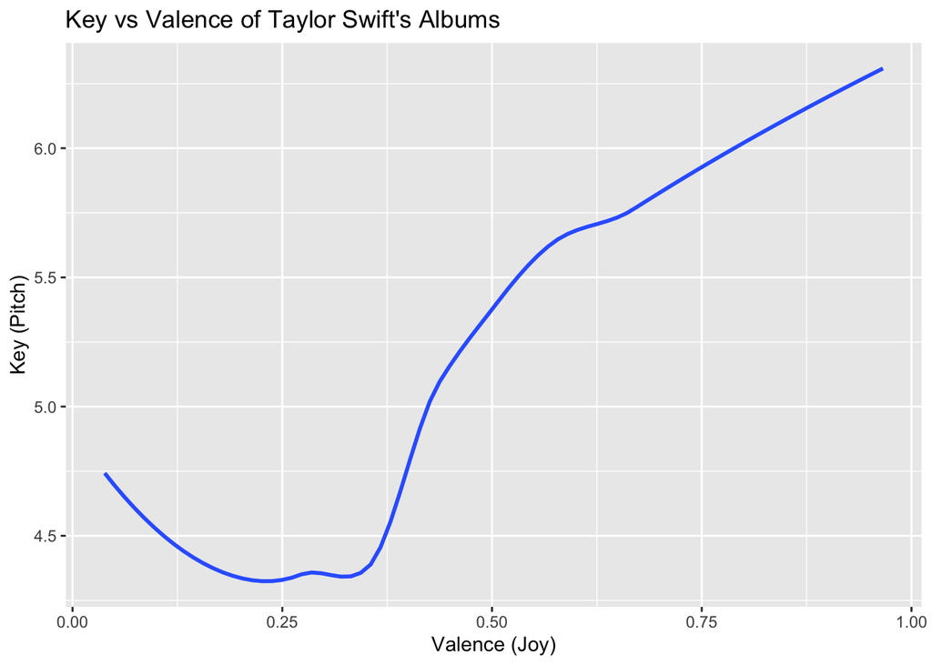

```r
library(spotifyr)

access_token <- get_spotify_access_token(
  client_id = Sys.getenv("SPOTIFY_CLIENT_ID"),
  client_secret = Sys.getenv("SPOTIFY_CLIENT_SECRET")
)

# Question: Is there a relationship between songs' pitch and the valence of Taylor Swift's albums?
# Based on the plot and the regression model we can conclude that there is significant positive coefficient between key and valence
taylorswift <- get_artist_audio_features('Taylor Swift', authorization = get_spotify_access_token())
taylorswift <- tibble(taylorswift)
taylorswift %>%
  ggplot(aes(x = valence, y = key)) +
  geom_smooth(se = F) +
  ggtitle("Key vs Valence of Taylor Swift's Albums") +
  xlab("Valence (Joy)") +
  ylab("Key (Pitch)")
```

```r
spreg.out <- lm(valence~key, data = taylorswift)
summary(spreg.out)
```

```
##
## Call:
## lm(formula = valence ~ key, data = taylorswift)
##
## Residuals:
##     Min      1Q  Median      3Q     Max
## -0.4361 -0.1606 -0.0059  0.1389  0.5494
##
## Coefficients:
##             Estimate Std. Error t value Pr(>|t|)
## (Intercept) 0.378598   0.014624  25.889  < 2e-16 ***
## key         0.011153   0.002463   4.528 7.08e-06 ***
## ---
## Signif. codes:  0 '***' 0.001 '**' 0.01 '*' 0.05 '.' 0.1 ' ' 1
##
## Residual standard error: 0.1974 on 647 degrees of freedom
## Multiple R-squared:  0.03072,    Adjusted R-squared:  0.02922
## F-statistic:  20.5 on 1 and 647 DF,  p-value: 7.083e-06
```

# 2 IMDB List of Oscar Winners

IMDB has a list of the [Oscar Best Picture Winners](https://www.imdb.com/search/title/?count=100&groups=oscar_best_picture_winners&sort=year%2Cdesc&ref_=nv_ch_osc).

Scrape the following elements, convert the data into a tibble, tidy it, and clean it to answer the questions below:

- Number
- Title
- Year
- MPAA Rating
- Length in minutes
- Genre
- Star Rating
- Metascore Rating
- Gross Receipts

Convert the data into a tibble, tidy it, and clean it to answer the following questions:

```r
html_obj <- read_html("Best_Picture_ IMDb.html")
html_obj
```

```
## {html_document}
## <html xmlns:og="http://ogp.me/ns#" xmlns:fb="http://www.facebook.com/2008/fbml">
## [1] <head>\n<meta http-equiv="Content-Type" content="text/html; charset=UTF-8 ...
## [2] <body id="styleguide-v2" class="fixed">\n        \n\n<script>\n!function( ...
```

```r
# get movie titles
oscar_titles <- html_nodes(html_obj,
                               css = ".lister-item-header a , .text-primary")
head(oscar_titles)
```

```
## {xml_nodeset (6)}
## [1] <span class="lister-item-index unbold text-primary">1.</span>
## [2] <a href="/title/tt6751668/?ref_=adv_li_tt">Parasite</a>
## [3] <span class="lister-item-index unbold text-primary">2.</span>
## [4] <a href="/title/tt6966692/?ref_=adv_li_tt">Green Book</a>
## [5] <span class="lister-item-index unbold text-primary">3.</span>
## [6] <a href="/title/tt5580390/?ref_=adv_li_tt">The Shape of Water</a>
```

```r
titles_text <- html_text(oscar_titles)
length(titles_text)
```

```
## [1] 186
```

```r
titles_df <- tibble(text = titles_text)

titles_df %>%
  mutate(ismovierank = str_detect(text, "^\\d+\\.$")) %>%
  filter(ismovierank == FALSE) %>%
  mutate(rownum = row_number()) %>%
  select(rownum, text, -ismovierank) %>%
  rename(rank = rownum,
         movie = text) ->
  movie_titles
head(movie_titles)
```

```
## # A tibble: 6 x 2
##    rank movie
##   <int> <chr>
## 1     1 Parasite
## 2     2 Green Book
## 3     3 The Shape of Water
## 4     4 Moonlight
## 5     5 Spotlight
## 6     6 Birdman or (The Unexpected Virtue of Ignorance)
```

```r
oscar_winners <- html_nodes(html_obj,
                               css = ".ghost~ .text-muted+ span , .favorable , .ratings-imdb-rating strong , .genre , .runtime , .certificate , .unbold , .lister-item-header a")
head(oscar_winners)
```

```
## {xml_nodeset (6)}
## [1] <span class="lister-item-index unbold text-primary">1.</span>
## [2] <a href="/title/tt6751668/?ref_=adv_li_tt">Parasite</a>
## [3] <span class="lister-item-year text-muted unbold">(2019)</span>
## [4] <span class="certificate">R</span>
## [5] <span class="runtime">132 min</span>
## [6] <span class="genre">\nComedy, Drama, Thriller            </span>
```

```r
ratings_text <- html_text(oscar_winners)
length(ratings_text)
```

```
## [1] 810
```

```r
oscar_df <- tibble(text = ratings_text)
  oscar_df %>%
    mutate(ismovierank = str_detect(text, "^\\d+\\.$")) -> # find sth like "1."
    oscar_df
```

```r
# add cumsum
oscar_df %>%
  mutate(movienum = cumsum(ismovierank)) ->
  oscar_df

# define movie titles
oscar_df %>%
  mutate(isname = text %in% movie_titles$movie) ->
  oscar_df

# define years
oscar_df %>%
  mutate(isyear = str_detect(text, "\\(\\d+\\)")) ->
  oscar_df

# define MPAA ratings (last step)

# define length in minutes
oscar_df %>%
  mutate(islength = str_detect(text, "^\\d+\\smin$")) ->
  oscar_df

# define genre
oscar_df %>%
  mutate(isgenre = str_detect(text, "^\\n")) ->
  oscar_df

# define star ratings
oscar_df %>%
  mutate(isstar = str_detect(text, "^\\d\\.\\d$")) ->
  oscar_df

# define Metascore
oscar_df %>%
  mutate(ismeta = str_detect(text, "^\\d+\\s+$")) ->
  oscar_df

# define gross
oscar_df %>%
  mutate(isgross = str_detect(text, "^\\$\\d+\\.\\d+M$")) ->
  oscar_df

# define MPAA
oscar_df %>%
  mutate(ismpaa = !ismovierank & !isname & !isyear & !isgenre & !islength & !isstar & !ismeta & !isgross) ->
  oscar_df
```

```r
#
oscar_df %>%
  mutate(key = case_when(
    ismovierank ~ "rank",
    isname ~ "movie",
    isyear ~ "year",
    ismpaa ~ "mpaa",
    islength ~ "length",
    isgenre ~ "genre",
    isstar ~ "star_rating",
    ismeta ~ "metascore",
    isgross ~ "gross")) %>%
  select(movienum, key, text) %>%
  pivot_wider(names_from = key, values_from = text) ->
  oscar_movies
oscar_movies
```

```
## # A tibble: 93 x 10
##    movienum rank  movie   year   mpaa  length genre  star_rating metascore gross
##       <int> <chr> <chr>   <chr>  <chr> <chr>  <chr>  <chr>       <chr>     <chr>
##  1        1 1.    Parasi… (2019) R     132 m… "\nCo… 8.6         "96     … $53.…
##  2        2 2.    Green … (2018) PG-13 130 m… "\nBi… 8.2         "69     … $85.…
##  3        3 3.    The Sh… (2017) R     123 m… "\nAd… 7.3         "87     … $63.…
##  4        4 4.    Moonli… (I) (… R     111 m… "\nDr… 7.4         "99     … $27.…
##  5        5 5.    Spotli… (I) (… R     129 m… "\nBi… 8.1         "93     … $45.…
##  6        6 6.    Birdma… (2014) R     119 m… "\nCo… 7.7         "87     … $42.…
##  7        7 7.    12 Yea… (2013) R     134 m… "\nBi… 8.1         "96     … $56.…
##  8        8 8.    Argo    (2012) R     120 m… "\nBi… 7.7         "86     … $136…
##  9        9 9.    The Ar… (I) (… PG-13 100 m… "\nCo… 7.9         "89     … $44.…
## 10       10 10.   The Ki… (2010) R     118 m… "\nBi… 8.0         "88     … $138…
## # … with 83 more rows
```

```r
oscar_movies %>%
  mutate(rank = parse_number(rank),
         year = parse_number(year),
         length = parse_number(length),
         genre = str_replace_all(genre, "\\n", ""),
         genre = str_squish(genre),
         star_rating = parse_number(star_rating),
         metascore = parse_number(metascore),
         gross = parse_number(gross),
         movienum = NULL) ->
  oscar_movies
oscar_movies
```

```
## # A tibble: 93 x 9
##     rank movie           year mpaa  length genre     star_rating metascore gross
##    <dbl> <chr>          <dbl> <chr>  <dbl> <chr>           <dbl>     <dbl> <dbl>
##  1     1 Parasite        2019 R        132 Comedy, …         8.6        96  53.4
##  2     2 Green Book      2018 PG-13    130 Biograph…         8.2        69  85.1
##  3     3 The Shape of …  2017 R        123 Adventur…         7.3        87  63.9
##  4     4 Moonlight       2016 R        111 Drama             7.4        99  27.8
##  5     5 Spotlight       2015 R        129 Biograph…         8.1        93  45.1
##  6     6 Birdman or (T…  2014 R        119 Comedy, …         7.7        87  42.3
##  7     7 12 Years a Sl…  2013 R        134 Biograph…         8.1        96  56.7
##  8     8 Argo            2012 R        120 Biograph…         7.7        86 136.
##  9     9 The Artist      2011 PG-13    100 Comedy, …         7.9        89  44.7
## 10    10 The King's Sp…  2010 R        118 Biograph…         8          88 139.
## # … with 83 more rows
```

1. Show a summary of the number of data elements for each movie that are not NA. Which two elements are missing the most from the movies? Metascore Rating and Gross Receipts

```r
oscar_movies %>%
  is.na() %>%
  colSums()
```

```
##        rank       movie        year        mpaa      length       genre
##           0           0           0           0           0           0
## star_rating   metascore       gross
##           0          17          10
```

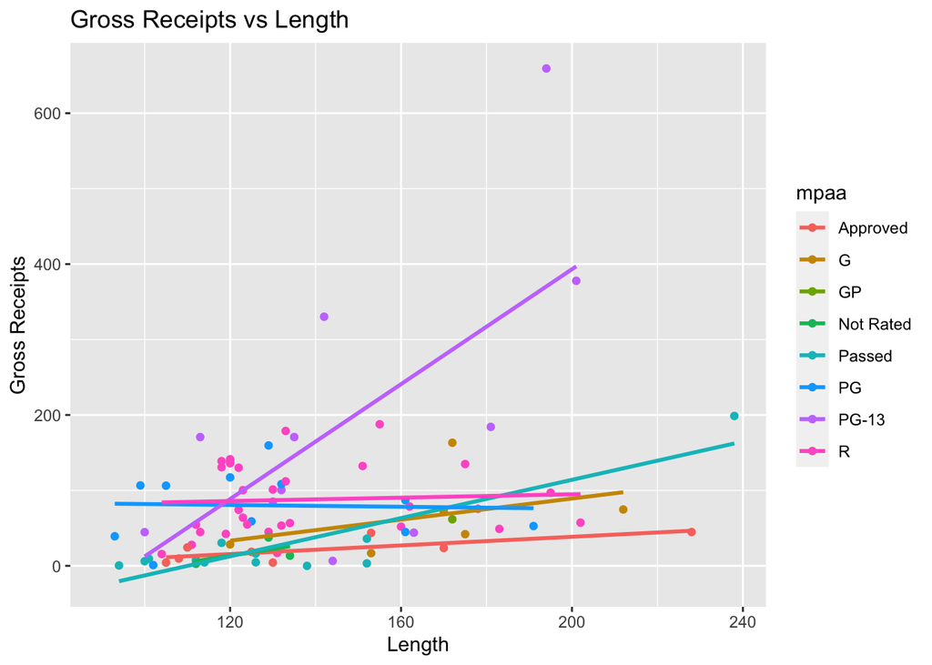

```r
oscar_movies %>%
  ggplot(aes(x = length, y = gross, col = mpaa)) +
  geom_point() +
  geom_smooth(se = FALSE, method = lm) +
  ggtitle("Gross Receipts vs Length") +
  xlab("Length") +
  ylab("Gross Receipts")
```

3. Create a plot with a single Ordinary Least Squares smoothing line with no standard errors showing for predicting stars rating based on metacritic scores for those movies that have metacritic scores.
- Use a linear model to assess if there is a meaningful relationship. Show the summary of the output and interpret in terms of the $p$-value and the adjusted R-Squared?

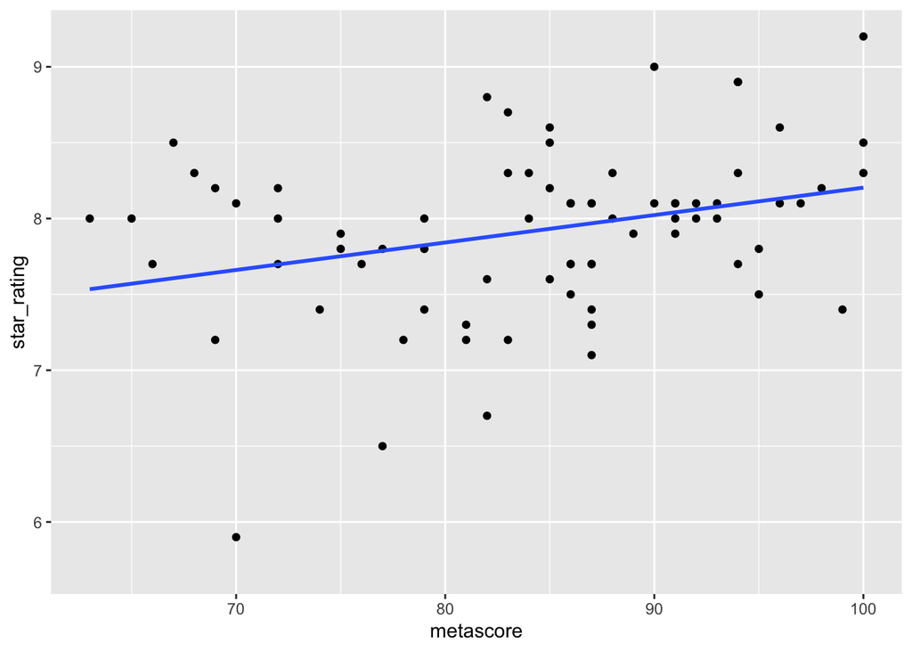

```r
oscar_movies %>%
  ggplot(aes(x = metascore, y = star_rating)) +
  geom_point() +
  geom_smooth(se = FALSE, method = lm)
```

```r
reg.out <- lm(star_rating~metascore, data = oscar_movies)
summary(reg.out)
```

```
##
## Call:
## lm(formula = star_rating ~ metascore, data = oscar_movies)
##
## Residuals:
##     Min      1Q  Median      3Q     Max
## -1.7609 -0.2868  0.0369  0.3055  0.9965
##
## Coefficients:
##             Estimate Std. Error t value Pr(>|t|)
## (Intercept) 6.394875   0.557866  11.463  < 2e-16 ***
## metascore   0.018087   0.006572   2.752  0.00744 **
## ---
## Signif. codes:  0 '***' 0.001 '**' 0.01 '*' 0.05 '.' 0.1 ' ' 1
##
## Residual standard error: 0.5297 on 74 degrees of freedom
##   (17 observations deleted due to missingness)
## Multiple R-squared:  0.09285,    Adjusted R-squared:  0.08059
## F-statistic: 7.574 on 1 and 74 DF,  p-value: 0.007443
```

```r
# p-value < 0.05, meaning there is a significant relationship between star and metascore ratings
# adjusted R-squared 0.08059, approximately 8% of the model is explained by the model, not a good model
```

4. Use an appropriate plot to compare the gross receipts by MPAA rating.
- Which MPAA rating has the highest median gross receipts?
- Which R-rated movies are in the overall top 10 of gross receipts?
- Use one-way analysis of variance to assess the level of evidence for whether all ratings have the same mean gross receipts. Show the summary of the results and provide your interpretation of the results.

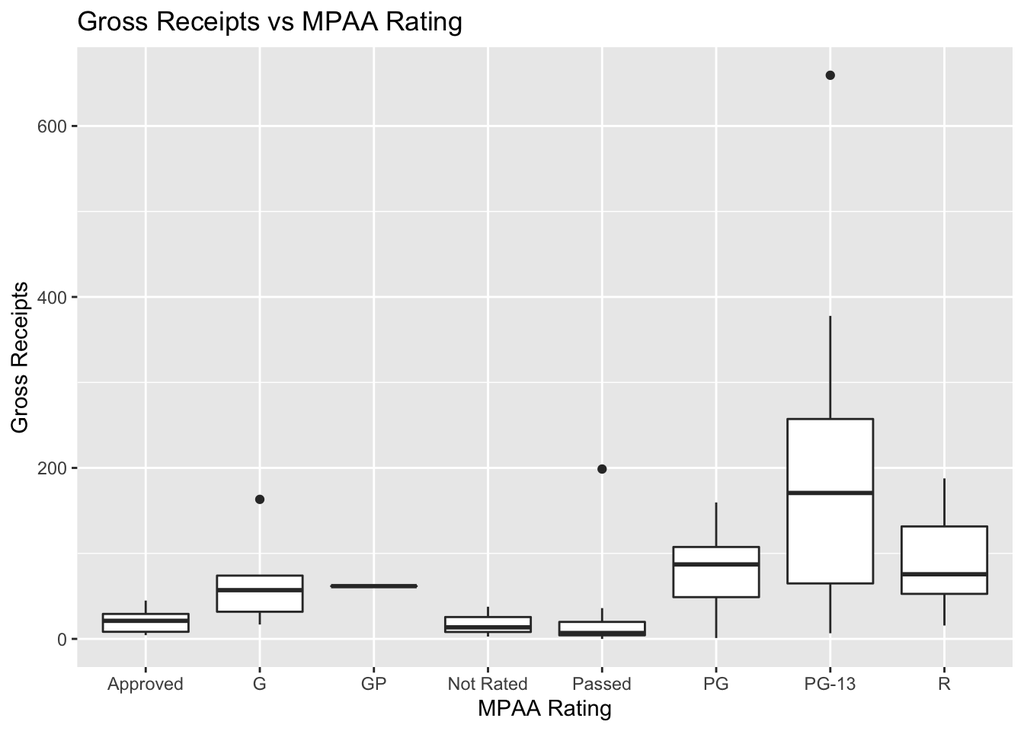

```r
oscar_movies %>%
  ggplot(aes(x = mpaa, y = gross)) +
  geom_boxplot() +
  ggtitle("Gross Receipts vs MPAA Rating") +
  xlab("MPAA Rating") +
  ylab("Gross Receipts")
```

```r
# Which MPAA rating has the highest median gross receipts? PG-13
oscar_movies %>%
  filter(!is.na(gross)) %>%
  group_by(mpaa) %>%
  summarise(median_gross = median(gross)) %>%
  arrange(desc(median_gross))
```

```
## # A tibble: 8 x 2
##   mpaa      median_gross
##   <chr>            <dbl>
## 1 PG-13           171.
## 2 PG               87.1
## 3 R                75.6
## 4 GP               61.7
## 5 G                57
## 6 Approved         21.1
## 7 Not Rated        13.5
## 8 Passed            6.88
```

```r
# Which R-rated movies are in the overall top 10 of gross receipts? Gladiator, Rain Man
oscar_movies %>%
  select(movie, mpaa, gross) %>%
  arrange(desc(gross)) %>%
  slice(1:10) %>%
  filter(mpaa == "R")
```

```
## # A tibble: 2 x 3
##   movie     mpaa  gross
##   <chr>     <chr> <dbl>
## 1 Gladiator R      188.
## 2 Rain Man  R      179.
```

```r
# ANOVA
# interpret: p-value is 0.0001579 < 0.05, so we have enough evidence to reject null hypothesis which all ratings have the same mean gross receipts. Not all means are equal (at least one pair of means is not equal)
model.fit = lm(gross~mpaa, data = oscar_movies)
anova(model.fit)
```

```
## Analysis of Variance Table
##
## Response: gross
##           Df Sum Sq Mean Sq F value    Pr(>F)
## mpaa       7 228480   32640   4.828 0.0001579 ***
## Residuals 75 507046    6761
## ---
## Signif. codes:  0 '***' 0.001 '**' 0.01 '*' 0.05 '.' 0.1 ' ' 1
```

# 3 Extra Credit 1 Pts

- Listen to the AI Today podcast on [Machine Learning Ops](https://podcasts.apple.com/us/podcast/ai-today-podcast-artificial-intelligence-insights-experts/id1279927057?i=1000468771571) and provide your thoughts on the following questions:
1. Does knowing about Git and GitHub help you in understanding the podcast?
- Yes, the speaker talked about the challenges they faced which is often related to the version control. He mentioned that developers using github and if not knowing how git and github works I might not understand when speaking of pull and push when manipulating the data.
2. How do you think the ideas of MLOPs will affect your future data science projects?
- I think it will be more efficiency. The speaker introduces that MLOPs is about the merge of engineering, machine learning and dev-ops, so processing through writing the concept, developing, testing and actually running the project, it will reduces the gap of communication.

You may also want to check out this article on [Towards Data Science](https://towardsdatascience.com/ml-ops-machine-learning-as-an-engineering-discipline-b86ca4874a3f)